# Predição de Eleições

Primeiro carregamos e estudamos os dados, e carregamos também as bibliotecas importantes para o desenvolvimento do projeto.

```r
library("tidyverse")
library("caret")
library("dplyr")
data <- read_delim("data/DESAFIO HACKATON DEZEMBRO 2018.csv",
     ";", escape_double = FALSE, trim_ws = TRUE)
```

# Dividindo conjuntos masculinos e femininos

Inicialmente, decidimos agrupar os dados em dois conjuntos, os femininos e os masculinos, já que haviam algumas perguntas eram respondidas somente por pessoas de um unico sexo

```r
masculinos <- subset(data, data$`P0006-SEXO` == "0002-MASCULINO")
femininos <- subset(data, data$`P0006-SEXO` == "0001-FEMININO")
mascProp <- (length(masculinos$PESQUISADOR) / length(data$PESQUISADOR)) * 100
femProp <- (length(femininos$PESQUISADOR) / length(data$PESQUISADOR)) * 100
mascProp
```

```
[1] 48.12878
```

```r
femProp
```

```
[1] 51.87122
```

Acima estão as proporções de homens e mulheres que participaram da pesquisa

# Prevendo o resultado das eleições

Aqui começamos o processo de prever o resultado das eleições em questão.

Criamos um conjunto de votos válidos, onde removemos os que não sabiam, não responderam e não votariam em nenhum dos dois candidatos.

```r
EleitoresFemininosDeFdePapai <- subset(femininos, femininos$`P0013-SE AS ELEIÇÕES PARA GOVERNADOR DE CAFUÇU FOSSEM HOJE, EM QUAL DESTES CANDIDATOS O (A) SR. (A) VOTARIA? (ESTIMULADA RU)` == "0001-FILHO DE PAPAI (PSB)")
EleitoresFemininosDePescGrosso <- subset(femininos, femininos$`P0013-SE AS ELEIÇÕES PARA GOVERNADOR DE CAFUÇU FOSSEM HOJE, EM QUAL DESTES CANDIDATOS O (A) SR. (A) VOTARIA? (ESTIMULADA RU)` == "0002-PESCOÇO GROSSO (PSD)")
outrosFemin <- subset(femininos, femininos$`P0013-SE AS ELEIÇÕES PARA GOVERNADOR DE CAFUÇU FOSSEM HOJE, EM QUAL DESTES CANDIDATOS O (A) SR. (A) VOTARIA? (ESTIMULADA RU)` != "0001-FILHO DE PAPAI (PSB)")
outrosFemin <- subset(outrosFemin, outrosFemin$`P0013-SE AS ELEIÇÕES PARA GOVERNADOR DE CAFUÇU FOSSEM HOJE, EM QUAL DESTES CANDIDATOS O (A) SR. (A) VOTARIA? (ESTIMULADA RU)` != "0002-PESCOÇO GROSSO (PSD)")
propFilhoDePapai <- length(EleitoresFemininosDeFdePapai$PESQUISADOR) / length(femininos$PESQUISADOR)
propPescGrosso <- length(EleitoresFemininosDePescGrosso$PESQUISADOR) / length(femininos$PESQUISADOR)
propOutros <- length(outrosFemin$PESQUISADOR) / length(femininos$PESQUISADOR)
```

Decidimos exibir as proporções de dados femininos e masculinos para enxergar a direção das pesquisas

### Resultados Gerais nas Pesquisas para Mulheres

```r
propFilhoDePapai
```

```
[1] 0.3225464
```

```r
propPescGrosso
```

```
[1] 0.4668435
```

```r
propOutros
```

```
[1] 0.2106101
```

Acima temos as proporções de intençoes de votos femininos para os candidatos 0001-FILHO DE PAPAI (PSB) e 0002-PESCOÇO GROSSO (PSD) e os outros, ou seja, os que não escolheram nem um nem outor, não respoderam, ou não sabiam.

```r
EleitoresMascDeFdePapai <- subset(masculinos, masculinos$`P0013-SE AS ELEIÇÕES PARA GOVERNADOR DE CAFUÇU FOSSEM HOJE, EM QUAL DESTES CANDIDATOS O (A) SR. (A) VOTARIA? (ESTIMULADA RU)` == "0001-FILHO DE PAPAI (PSB)")
EleitoresMascDePescGrosso <- subset(masculinos, masculinos$`P0013-SE AS ELEIÇÕES PARA GOVERNADOR DE CAFUÇU FOSSEM HOJE, EM QUAL DESTES CANDIDATOS O (A) SR. (A) VOTARIA? (ESTIMULADA RU)` == "0002-PESCOÇO GROSSO (PSD)")
outrosMasc <- subset(masculinos, masculinos$`P0013-SE AS ELEIÇÕES PARA GOVERNADOR DE CAFUÇU FOSSEM HOJE, EM QUAL DESTES CANDIDATOS O (A) SR. (A) VOTARIA? (ESTIMULADA RU)` != "0001-FILHO DE PAPAI (PSB)")
outrosMasc <- subset(outrosMasc, outrosMasc$`P0013-SE AS ELEIÇÕES PARA GOVERNADOR DE CAFUÇU FOSSEM HOJE, EM QUAL DESTES CANDIDATOS O (A) SR. (A) VOTARIA? (ESTIMULADA RU)` != "0002-PESCOÇO GROSSO (PSD)")
propFilhoDePapai <- length(EleitoresMascDeFdePapai$PESQUISADOR) / length(masculinos$PESQUISADOR)
propPescGrosso <- length(EleitoresMascDePescGrosso$PESQUISADOR) / length(masculinos$PESQUISADOR)
propOutros <- length(outrosMasc$PESQUISADOR) / length(masculinos$PESQUISADOR)
```

### Resultados gerais nas pesquisas para homens

```r
propFilhoDePapai
```

```
[1] 0.348199
```

```r
propPescGrosso
```

```
[1] 0.4722699
```

```r
propOutros
```

```
[1] 0.1795312
```

Acima temos as proporções de intençoes de votos masculinos para os candidatos 0001-FILHO DE PAPAI (PSB) e 0002-PESCOÇO GROSSO (PSD) e os outros, ou seja, os que não escolheram nem um nem outor, não respoderam, ou não sabiam.

## Status geral

Abaixo plotamos uma visualização de como andaram as pesquisas de acordo com o dia

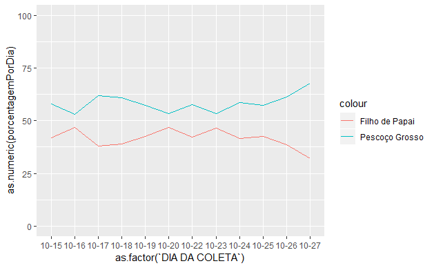

```r
DESAFIO_HACKATON_DEZEMBRO_2018 <- data
DESAFIO_HACKATON_DEZEMBRO_2018$`DIA DA COLETA` <- substr(DESAFIO_HACKATON_DEZEMBRO_2018$`FIM COLETA`,6,10)
#votos para pescoço grosso
respostasPC <- subset(DESAFIO_HACKATON_DEZEMBRO_2018,DESAFIO_HACKATON_DEZEMBRO_2018$`P0013-SE AS ELEIÇÕES PARA GOVERNADOR DE CAFUÇU FOSSEM HOJE, EM QUAL DESTES CANDIDATOS O (A) SR. (A) VOTARIA? (ESTIMULADA RU)` == "0002-PESCOÇO GROSSO (PSD)")
#votos para filho de papai
respostasFP <- subset(DESAFIO_HACKATON_DEZEMBRO_2018,DESAFIO_HACKATON_DEZEMBRO_2018$`P0013-SE AS ELEIÇÕES PARA GOVERNADOR DE CAFUÇU FOSSEM HOJE, EM QUAL DESTES CANDIDATOS O (A) SR. (A) VOTARIA? (ESTIMULADA RU)` == "0001-FILHO DE PAPAI (PSB)")
respostasGovernador <- rbind(respostasFP, respostasPC)
#votos totais por dia
respostasGovernadorPorData <- respostasGovernador %>% group_by(`DIA DA COLETA`) %>% summarise(porcentagemPorDia = length(`DIA DA COLETA`))
#votos para pescoço grosso por dia
respostasPGporData <- respostasPC %>% group_by(`DIA DA COLETA`) %>% summarise(votosParaPG = length(`DIA DA COLETA`))
respostasFPporData <- respostasFP %>% group_by(`DIA DA COLETA`) %>% summarise(votosParaFP = length(`DIA DA COLETA`))
respostasGovernadorPorDataAmbos <- respostasGovernadorPorData
respostasGovernadorPorDataAmbos$votosParaPG <- respostasPGporData$votosParaPG
respostasGovernadorPorDataAmbos$votosParaFP <- respostasFPporData$votosParaFP
plotVotacoesDiarias <- ggplot(data = respostasGovernadorPorDataAmbos, aes(x = as.factor(`DIA DA COLETA`), y = as.numeric(porcentagemPorDia) ,group=1)) + geom_line(aes(y = 100*(votosParaPG/porcentagemPorDia), color="Pescoço Grosso"))+ geom_line(aes(y = 100*(votosParaFP/porcentagemPorDia) , color="Filho de Papai"))+scale_y_continuous(limits =c(0,100))
plotVotacoesDiarias
```

### Modelo de Predição

Por fim, construimos nossos modelo de predição baseado em uma regressão logistica, que usou os parametros para estimar a votação de cada um dos eleitores, inclusive dos eleitores que nao responderam ou não sabiam

```r
data$`P0011-EM QUAIS DESTES MEIOS DE COMUNICAÇÃO O (A) SR. (A) TEM ASSISTIDO OU OUVIDO A PROPAGANDA POLÍTICA DESTA ELEIÇÃO? (RM ESTIMULADA)(F)` <- NULL
data$`P0011-EM QUAIS DESTES MEIOS DE COMUNICAÇÃO O (A) SR. (A) TEM ASSISTIDO OU OUVIDO A PROPAGANDA POLÍTICA DESTA ELEIÇÃO? (RM ESTIMULADA)(E)` <- NULL
data$`P0011-EM QUAIS DESTES MEIOS DE COMUNICAÇÃO O (A) SR. (A) TEM ASSISTIDO OU OUVIDO A PROPAGANDA POLÍTICA DESTA ELEIÇÃO? (RM ESTIMULADA)(D)` <- NULL
data$`P0011-EM QUAIS DESTES MEIOS DE COMUNICAÇÃO O (A) SR. (A) TEM ASSISTIDO OU OUVIDO A PROPAGANDA POLÍTICA DESTA ELEIÇÃO? (RM ESTIMULADA)(C)` <- NULL
data$`P0011-EM QUAIS DESTES MEIOS DE COMUNICAÇÃO O (A) SR. (A) TEM ASSISTIDO OU OUVIDO A PROPAGANDA POLÍTICA DESTA ELEIÇÃO? (RM ESTIMULADA)(B)` <- NULL
data$`P0011-EM QUAIS DESTES MEIOS DE COMUNICAÇÃO O (A) SR. (A) TEM ASSISTIDO OU OUVIDO A PROPAGANDA POLÍTICA DESTA ELEIÇÃO? (RM ESTIMULADA)(A)` <- NULL
data$PESQUISADOR <- NULL
data$QUESTIONARIO <- NULL
votosValidos <- subset(data, data$`P0013-SE AS ELEIÇÕES PARA GOVERNADOR DE CAFUÇU FOSSEM HOJE, EM QUAL DESTES CANDIDATOS O (A) SR. (A) VOTARIA? (ESTIMULADA RU)` == "0001-FILHO DE PAPAI (PSB)")
votosValidos <- rbind(votosValidos, subset(data, data$`P0013-SE AS ELEIÇÕES PARA GOVERNADOR DE CAFUÇU FOSSEM HOJE, EM QUAL DESTES CANDIDATOS O (A) SR. (A) VOTARIA? (ESTIMULADA RU)` == "0002-PESCOÇO GROSSO (PSD)"))
#Total de Votos Válidos
length(votosValidos$`P0006-SEXO`)
```

```
[1] 2923
```

```r
ctrl <- trainControl(method = "cv", number = 5, search = "random")
set.seed(2)
formula = as.formula(`P0013-SE AS ELEIÇÕES PARA GOVERNADOR DE CAFUÇU FOSSEM HOJE, EM QUAL DESTES CANDIDATOS O (A) SR. (A) VOTARIA? (ESTIMULADA RU)` ~.)
modelo.rl <- train(formula,
                   data = votosValidos,
                   method = "glm",
                   na.action = na.pass,
                   family = "binomial",
                   trControl = ctrl)
```

```
prediction from a rank-deficient fit may be misleadingprediction from a rank-deficient fit may be misleading
```

```r
#Acuracia
modelo.rl$results$Accuracy
```

```
[1] 0.9705743
```

```r
#Predizendo a votação dos eleitores de acordo com o modelo
#Prevendo os resultados de quem não respondeu e quem não sabe
votosFinais <- rbind(votosValidos,
                     subset(data, data$`P0013-SE AS ELEIÇÕES PARA GOVERNADOR DE CAFUÇU FOSSEM HOJE, EM QUAL DESTES CANDIDATOS O (A) SR. (A) VOTARIA? (ESTIMULADA RU)` == "0005-NÃO RESPONDEU"))
votosFinais <- rbind(votosFinais,
                     subset(data, data$`P0013-SE AS ELEIÇÕES PARA GOVERNADOR DE CAFUÇU FOSSEM HOJE, EM QUAL DESTES CANDIDATOS O (A) SR. (A) VOTARIA? (ESTIMULADA RU)` == "0004-NÃO SABE"))
votosFinais$Pred <- predict(modelo.rl, votosFinais)
propFinalPescGrosso <- subset(votosFinais, votosFinais$Pred == "0002-PESCOÇO GROSSO (PSD)")
propFinalPescGrosso <- length(propFinalPescGrosso$`P0001-REGIÃO`) / length(votosFinais$`P0001-REGIÃO`)
propFinalFilho <- subset(votosFinais, votosFinais$Pred == "0001-FILHO DE PAPAI (PSB)")
propFinalFilho <- length(propFinalFilho$`P0001-REGIÃO`) / length(votosFinais$`P0001-REGIÃO`)
propFinalFilho
```

```
[1] 0.408349
```

```r
propFinalPescGrosso
```

```
[1] 0.591651
```

Acima temos a proporção final da nossa predição. Nossos resultados apontam que o candidato Pescoço Grosso vence as eleições com 59.1% dos votos válidos contra 40% do candidato Filho de Papai

## Variáveis importantes

Ao prever o resultado utilizando um modelo de regressão logistica, podemos inferir as variáveis mais importantes para a estrutura do modelo, e consideramos que elas sejam as variaveis mais importantes no contexto geral, elas melhor descrevem nossa variável principal.

```r
varImp(modelo.rl)
```

```
glm variable importance

  only 20 most important variables shown (out of 66)
```

|  | Overall |
| --- | --- |
| `\\`P0012-(APENAS PARA QUEM ASSISTE/OUVE) QUAL DESSES CANDIDATOS A GOVERNADOR APRESENTOU AS MELHORES PROPOSTAS PARA CAFUÇU? (RU ESTIMULADA)\\`0002-PESCOÇO GROSSO (PSD)` | 100.00000 |
| `\\`P0012-(APENAS PARA QUEM ASSISTE/OUVE) QUAL DESSES CANDIDATOS A GOVERNADOR APRESENTOU AS MELHORES PROPOSTAS PARA CAFUÇU? (RU ESTIMULADA)\\`null-null` | 76.25353 |
| `\\`P0012-(APENAS PARA QUEM ASSISTE/OUVE) QUAL DESSES CANDIDATOS A GOVERNADOR APRESENTOU AS MELHORES PROPOSTAS PARA CAFUÇU? (RU ESTIMULADA)\\`0004-NÃO SABE` | 64.92331 |
| `\\`P0022-SE O SENADOR ELEITO FICHA LIMPA APOIAR FILHO DE PAPAI PARA GOVERNADOR DE CAFUÇU, VOCÊ VOTARIA EM FILHO DE PAPAI NESTE SEGUNDO TURNO? (RU ESTIMULADA)\\`0003-NÃO VOTARIA DE JEITO NENHUM` | 61.58567 |
| `\\`P0012-(APENAS PARA QUEM ASSISTE/OUVE) QUAL DESSES CANDIDATOS A GOVERNADOR APRESENTOU AS MELHORES PROPOSTAS PARA CAFUÇU? (RU ESTIMULADA)\\`0003-NENHUM DELES` | 39.69556 |
| `\\`P0020-(APENAS PARA FILHO DE PAPAI) ESTÃO CONVICTOS DE REPETIR O VOTO EM FILHO DE PAPAI NO SEGUNDO TURNO? (RU ESTIMULADA)\\`0002-NÃO` | 39.26780 |
| `\\`P0022-SE O SENADOR ELEITO FICHA LIMPA APOIAR FILHO DE PAPAI PARA GOVERNADOR DE CAFUÇU, VOCÊ VOTARIA EM FILHO DE PAPAI NESTE SEGUNDO TURNO? (RU ESTIMULADA)\\`0004-NÃO SABE` | 38.34251 |
| `\\`P0021-(APENAS PARA PESCOÇO GROSSO) ESTÃO CONVICTOS DE REPETIR O VOTO EM PESCOÇO GROSSO NO SEGUNDO TURNO? (RU ESTIMULADA)\\`0002-NÃO` | 35.28303 |
| `\\`P0022-SE O SENADOR ELEITO FICHA LIMPA APOIAR FILHO DE PAPAI PARA GOVERNADOR DE CAFUÇU, VOCÊ VOTARIA EM FILHO DE PAPAI NESTE SEGUNDO TURNO? (RU ESTIMULADA)\\`0005-NÃO RESPONDEU` | 33.78900 |
| `\\`P0022-SE O SENADOR ELEITO FICHA LIMPA APOIAR FILHO DE PAPAI PARA GOVERNADOR DE CAFUÇU, VOCÊ VOTARIA EM FILHO DE PAPAI NESTE SEGUNDO TURNO? (RU ESTIMULADA)\\`0002-TALVEZ VOTARIA` | 30.75532 |

[output cut: 10 more lines]

## Dificuldades

- Sentimos dificuldade em utilizar a variável 11, sobre em qual local se informam os entrevistados, nossa ideia seria colapsar tal variável em uma unica coluna, mas isso nos tiraria muito tempo
- Estavamos em final de periodo, tava todo mundo cansado pós semana de provas
- Tempo também foi um fator limitante no que poderiamos desenvolver

## O que fariamos com mais tempo

#### Em cerca de 2 meses poderiamos

- Realizar testes estatisticos para estudar quão bem o conjunto de dados representa a população
- Testar variáveis de regressão logistica multipla, como RandomFlorests, para estudar o impacto das pessoas indecissas e comparar esses resultados com os modelos que já aplicamos, que utilizam duas classes
- Criar e comparar visualizações para entender melhor nossos resultados e como podemos melhora-los